# Les graphiques avec ggplot2

Antoine Sireyjol

7 janvier 2020

## Les graphiques dans R : illustration

R dispose de fonctions de base pour sortir des graphiques. On se concentre ici uniquement sur le package `ggplot2`, qui fait partie du `tidyverse`, et qui permet de sortir rapidement de beaux graphiques. Pendant votre pratique, vous pouvez vous appuyer en plus des autres sources que vous trouverez sur l’aide-mémoire en français détaillant les possibilités de ce package : https://thinkr.fr/pdf/ggplot2-french-cheatsheet.pdf.

On commence par un petit exemple. L’objectif sera de reproduire les graphiques suivants à partir de `df1`:

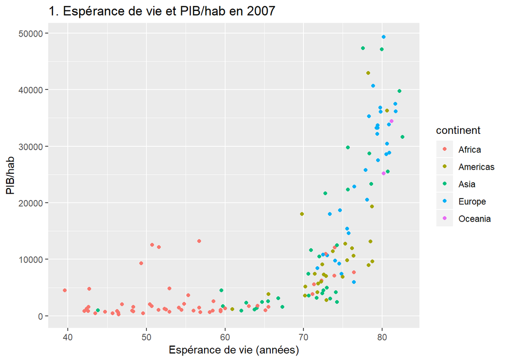

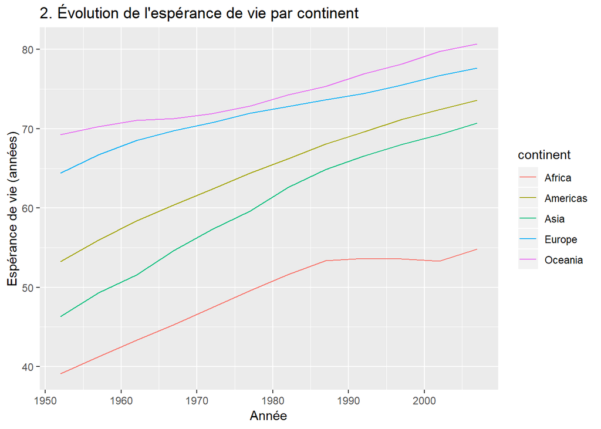

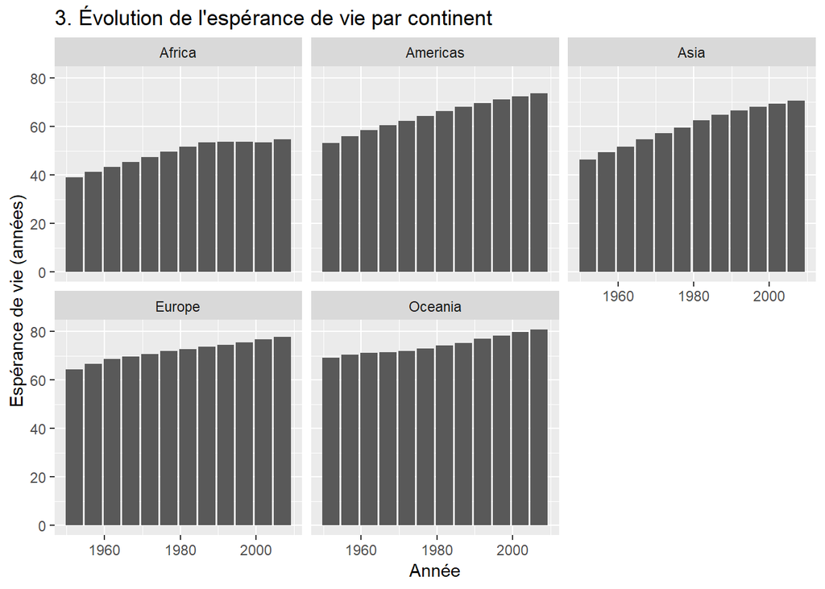

## Syntaxe de ggplot2

La syntaxe est la suivante : `ggplot(data = , aes(x = , y = ,....)` ou `data %>% ggplot(aes(x = , y = )`. Ces quelques lignes définissent le jeu de données sur lequel on travaille, et les coordonnées auxquelles on s’intéresse. On *initialise* en quelque sorte le graphique, mais sans indiquer à quoi il va ressembler. Dans notre exemple ces simples lignes de code donnent :

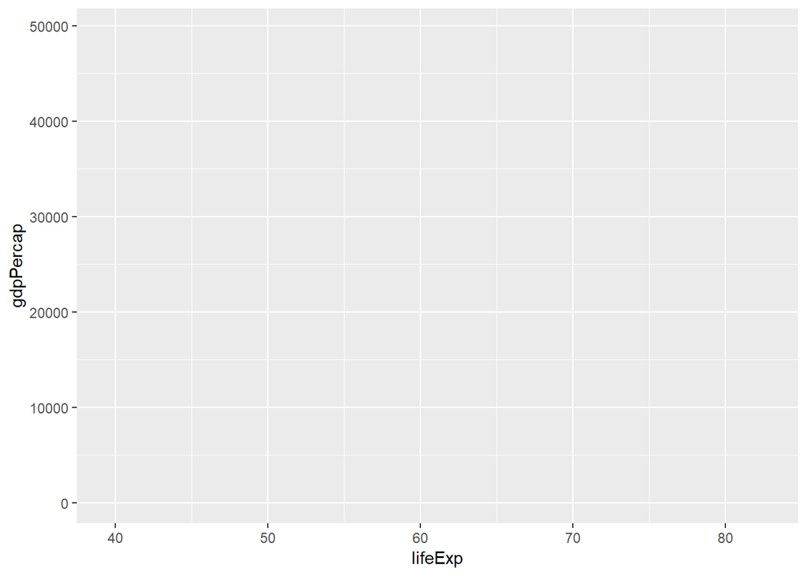

```r
library(ggplot2)
df1 %>% filter(year == 2007) %>%
  ggplot(aes(x = lifeExp, y = gdpPercap))
```

On a ainsi créé notre système de coordonnées, on va pouvoir maintenant ajouter autant de couches graphiques que l’on veut, grâce aux fonctions que vous découvrez par exemple dans l’aide mémoire. **Attention : Ces appels sont séparés par un `+`**. Si je veux un point par observation par exemple j’entre :

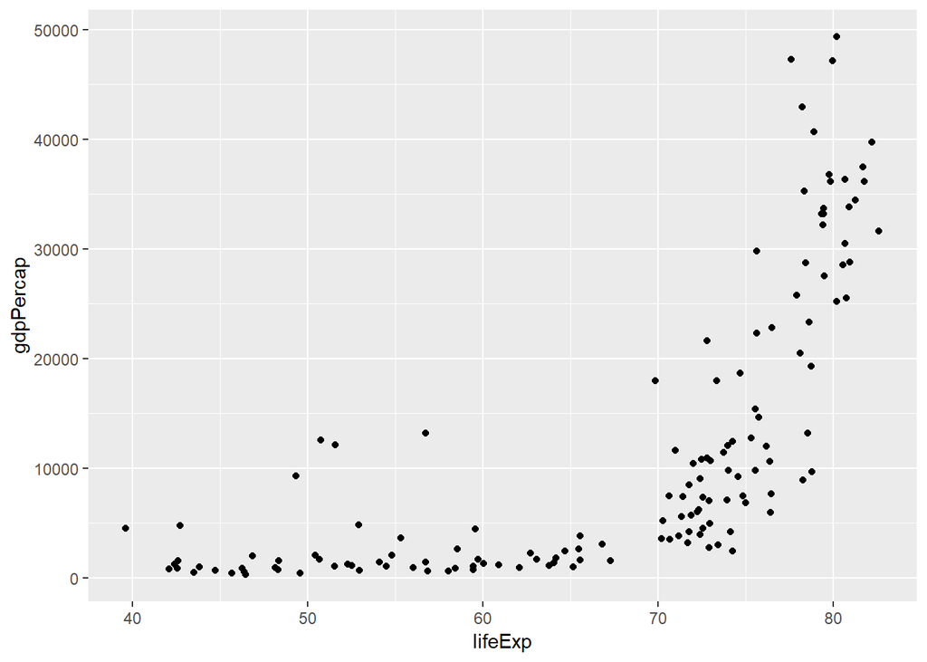

```r
library(dplyr)
library(ggplot2)
df1 %>% filter(year == 2007) %>%
  ggplot(aes(x = lifeExp, y = gdpPercap)) +
  geom_point()
```

Ou, si je veux en plus relier les points entre eux par exemple :

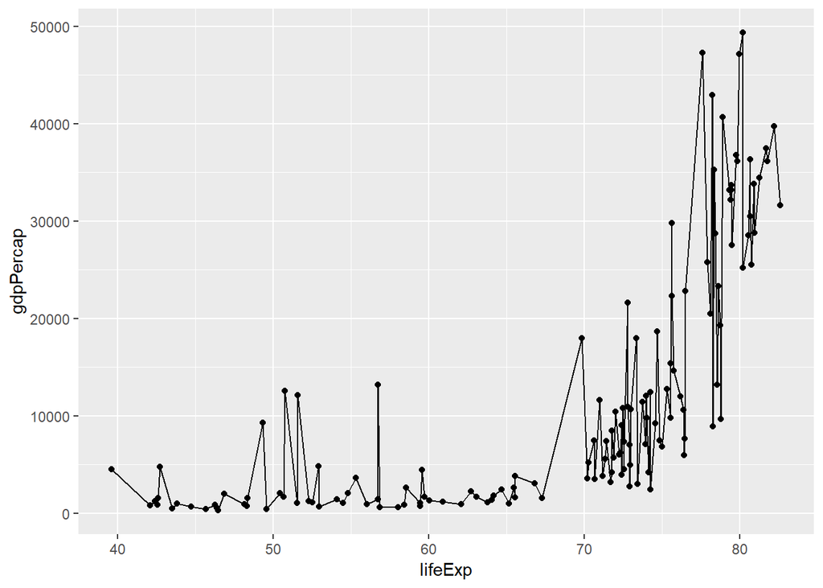

```r
library(ggplot2)
df1 %>% filter(year == 2007) %>%
  ggplot(aes(x = lifeExp, y = gdpPercap)) +
  geom_point() +
  geom_line()
```

1. Exercice : Trouvez comment changer la couleur des points de noir à rouge, puis comment donner une couleur différente par continent comme je l’ai fait dans mon exemple.
2. Essayez d’autres `geom_` sur ce même jeu de données.
3. Changez le titre principal et les titres des axes en utilisant la fonction `labs()` : vous avez maintenant tous les éléments pour reproduire le graphique 1!
4. Essayez de reproduire le sgraphiques 2. et 3. Avant de vous lancer trop vite, réfléchissez bien aux données en entrée de `ggplot()`.